# Lab 4: More Visualization with ggplot2

```r
library(dslabs)
library(dplyr)
library(ggplot2)
```

In this lab, we will be working more with the vaccination data and we will be practicing using ggplot2. The examples here attempt to show how a data scientist would approach a new dataset, and are intended to illustrate how `ggplot2` can be flexibly manipulated to create a variety of visualizations.

# Problem 1: Weeks reporting

In this problem, we will explore the `weeks_reporting` column in the vaccines data and its impact on the rate calculation.

```r
data(us_contagious_diseases)
```

1. Look at the help documentation for `us_contagious_diseases` and describe what `weeks_reporting` represents.

*Solution*: The `weeks_reporting` column counts the number of weeks counts were reported that year.

2. Draw a histogram of the `weeks_reporting` column for all states, all years, and all diseases combined.

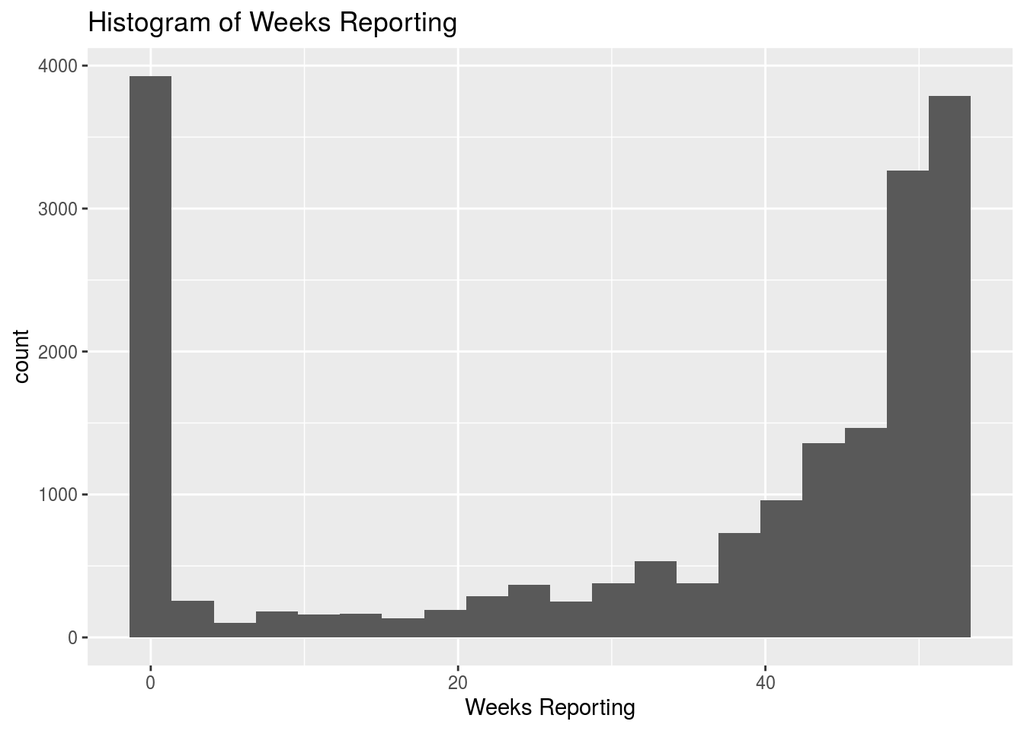

```r
us_contagious_diseases %>%
  ggplot(aes(x = weeks_reporting)) +
  geom_histogram(bins = 20) +
  xlab("Weeks Reporting") +
  ggtitle("Histogram of Weeks Reporting")
```

3. The histogram above aggregates the `weeks_reporting` for all states, all years, and all diseases combined. It could be possible that there are some diseases where the number of weeks reporting could be close to 52, and some diseases where the number of weeks reporting could be much less. Does the number of weeks reporting vary by disease? Use the `facet_wrap` function to explore this.

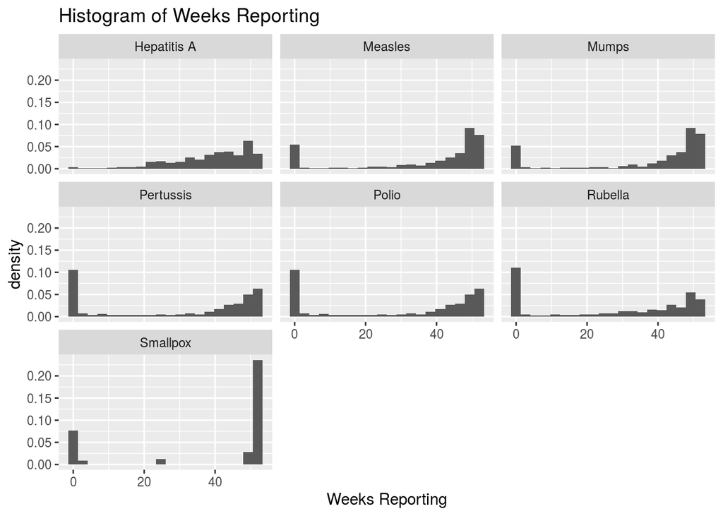

```r
us_contagious_diseases %>%
  ggplot(aes(x = weeks_reporting, y = ..density..)) +
  geom_histogram(bins = 20) +
  facet_wrap(~disease) +
  xlab("Weeks Reporting") +
  ggtitle("Histogram of Weeks Reporting")
```

4. Because the histogram above aggregates data on all states, it’s possible there are differences in weeks reporting by states as well. To answer this question, we can draw a boxplot by plotting the weeks reporting by state, and facetting by disease.

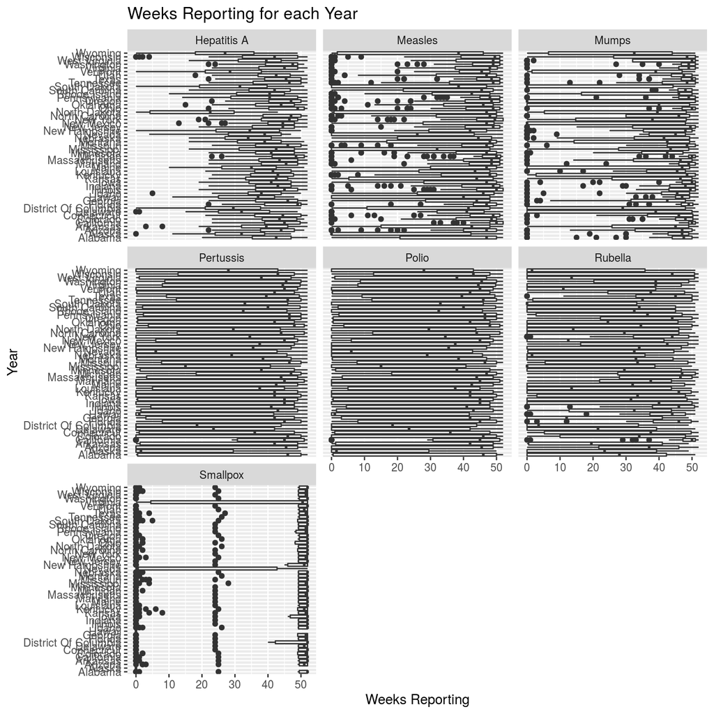

```r
us_contagious_diseases %>%
  ggplot(aes(x = state, y = weeks_reporting, group = state)) +
  geom_boxplot() +
  facet_wrap(~disease) +
  xlab("Year") + ylab("Weeks Reporting") +
  coord_flip() +
  ggtitle("Weeks Reporting for each Year")
```

5. If the above plot is hard to read, we might want to focus on one disease in particular. How can we revise the code in part (d) to only plot Pertussis?

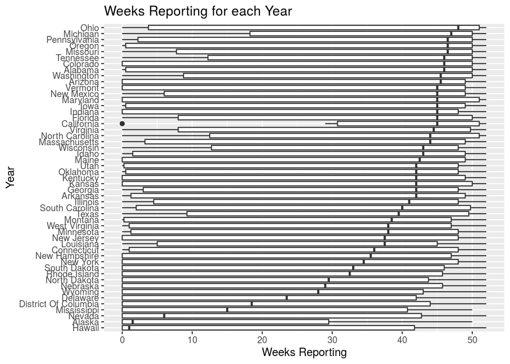

```r
us_contagious_diseases %>%
  filter(disease == "Pertussis") %>%
  ggplot(aes(x = reorder(state, weeks_reporting, median),
             y = weeks_reporting, group = state)) +
  geom_boxplot() +
  xlab("Year") + ylab("Weeks Reporting") +
  coord_flip() +
  ggtitle("Weeks Reporting for each Year")
```

# Problem 2: Improved Rate Calculation

Recall that last time we calculated the rate for each disease in each state in each year as the count divided by the population. Now that we’ve identified that we need to take into account differential weeks reporting in calculating the rate, let us amend the rate calculation.

1. Subset the data to exclude Alaska and Hawaii and include states-years with weeks reporting greater than 0.

```r
disease_subset <- us_contagious_diseases %>%
  filter(state != "Alaska", state != "Hawaii",
         weeks_reporting > 0)
```

2. Calculate the rate per 100,000, not taking into account weeks reporting. Call this the unadjusted rate.

```r
disease_subset <- disease_subset %>%
  mutate(raw_rate = count / population * 100000)
```

2. Now, take into account weeks reporting for vaccination data to calculate the rate. Call this the adjusted rate.

```r
disease_subset <- disease_subset %>%
  mutate(rate = 52 * (count / weeks_reporting) / population * 1e5)
```

3. Compare the adjusted vs. unadjusted rate to see if there is a difference. Make a scatter plot with one quantity on the x-axis and one quantity on the y-axis. Color each point by the number of weeks reporting. Include the identity line so we can more easily make comparisons.

In statistics, we often want to compare two quantities to see how they’re related. Do we see a relationship here? Looking back at the derivation of the new rate, is it clear why the new rate is greater than or equal to the previously calculated rate? Is there a relationship between the difference and the number of weeks reporting?

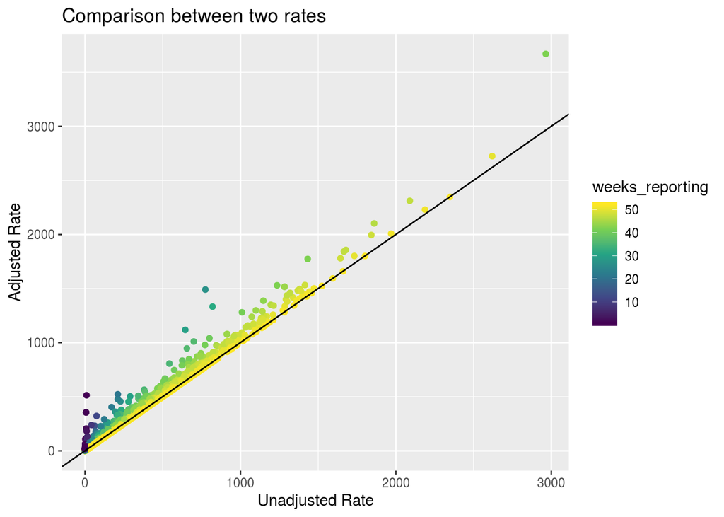

```r
disease_subset %>%
  ggplot(aes(x = raw_rate, y = rate, color = weeks_reporting)) +
  geom_point() +
  scale_color_viridis_c() +
  geom_abline(slope = 1, intercept = 1) +
  xlab("Unadjusted Rate") + ylab("Adjusted Rate") +
  ggtitle("Comparison between two rates")
```

*Solution*:

The adjusted rate is calculated as

$$r_{\text{adj}} = \frac{52}{\text{weeks
reporting}}\frac{\text{count}}{\text{population} / 100000}$$

The unadjusted rate is calculated as

$$r_{\text{unadj}} = \frac{\text{count}}{\text{population} / 100000}$$

So we can see that $r_{\text{adj}} = \frac{52}{\text{weeks reporting}} r_{\text{unadj}}$. Since $\text{weeks reporting} \leq 52$, we can see that $r_{\text{adj}} \geq r_{\text{adj}}$, with equality when weeks reporting is 52. This is also a decreasing function in terms of weeks reporting, so the difference between $r_{\text{adj}}$ and $r_{\text{unadj}}$ decreases as weeks reporting increases to 52.

# Problem 3

Now, we can apply the same principle to calculate the overall rate for each disease for the entire US.

1. For each disease and year, compute the overall rate for the entire US. Hint: You may want to use the `group_by` function.

```r
us_avg <- disease_subset %>%
  group_by(disease, year) %>%
  summarize(us_rate = sum(count / weeks_reporting * 52) / sum(population) * 1e5)
head(us_avg)
```

```
## # A tibble: 6 x 3
## # Groups:   disease [1]
##   disease      year us_rate
##   <fct>       <dbl>   <dbl>
## 1 Hepatitis A  1966    17.2
## 2 Hepatitis A  1967    20.1
## 3 Hepatitis A  1968    23.4
## 4 Hepatitis A  1969    24.5
## 5 Hepatitis A  1970    28.3
## 6 Hepatitis A  1971    29.6
```

2. Draw a plot of the correctly calculated overall rate for the entire US for each disease.

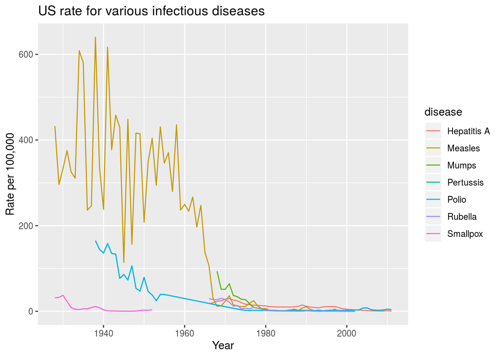

```r
us_avg %>%
  ggplot(aes(x = year, y = us_rate, color = disease)) +
  geom_line() +
  xlab("Year") + ylab("Rate per 100,000") +
  ggtitle("US rate for various infectious diseases")
```

# Problem 4

In this problem, we will explore some other types of visualization and data manipulation using the gapminder data.

1. Create a new dataframe called `gapminder_africa` which only includes countries from the gapminder dataset that are in the continent of Africa.

```r
data(gapminder)
gapminder_africa <- filter(gapminder, continent == "Africa")
```

2. We will explore the changes in population for each country over time. First, create a line graph for each country’s population over time.

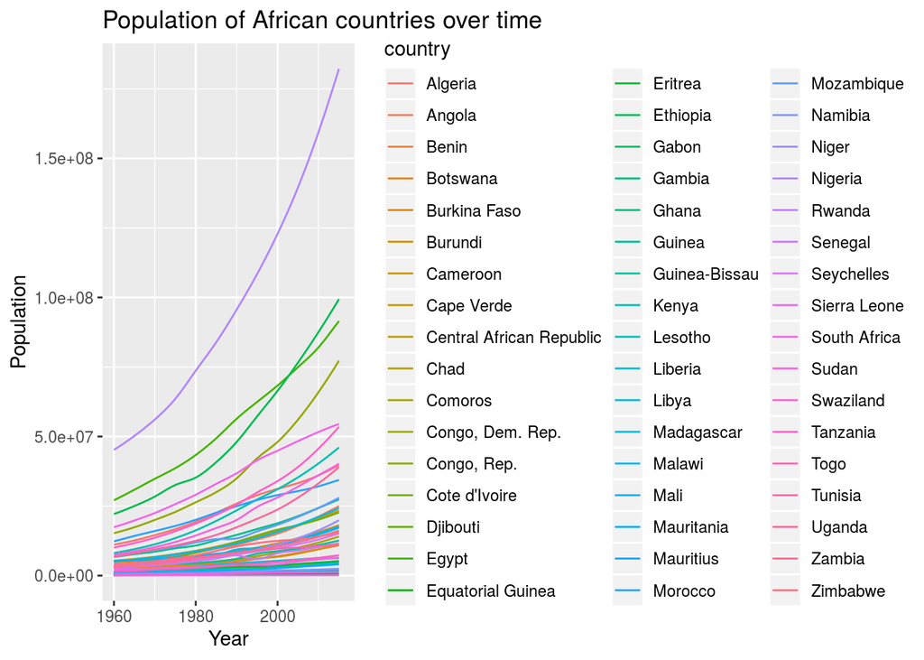

```r
gapminder_africa %>%
  ggplot(aes(x = year, y = population, color = country)) +
  geom_line() +
  xlab("Year") + ylab("Population") +
  ggtitle("Population of African countries over time")
```

3. We can see that the distribution of populations is highly skewed. There are a bunch of countries with lower populations that are all bunched up. We can fix this by performing a log10 transformation of the y-axis.

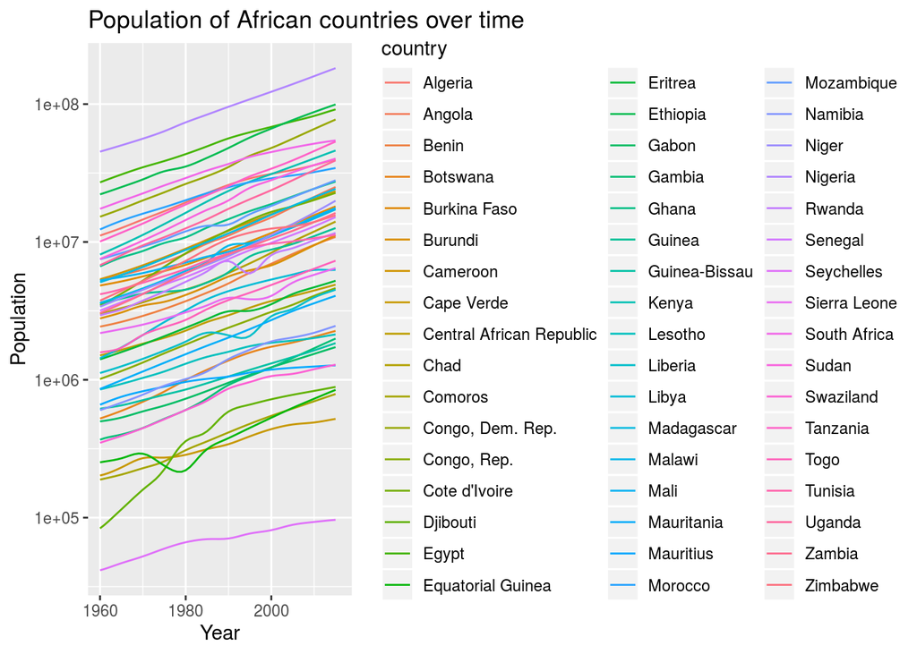

```r
gapminder_africa %>%
  ggplot(aes(x = year, y = population, color = country)) +
  geom_line() +
  scale_y_log10() +
  xlab("Year") + ylab("Population") +
  ggtitle("Population of African countries over time")
```

4. In the line graph in part (c), it is hard to see individual countries. Instead, we can make a tile plot of the population. Check out the `geom_tile` command and produce a tile plot of each country’s population over time. We can color each tile using the `fill` aesthetic.

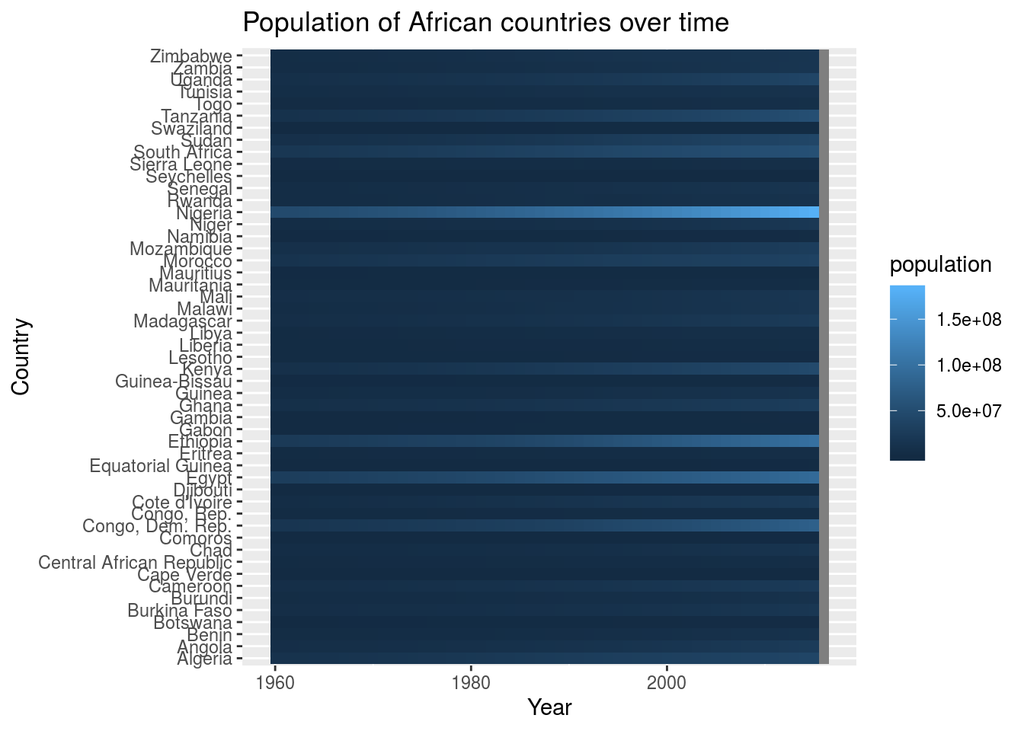

```r
gapminder_africa %>%
  ggplot(aes(x = year, y = country, fill = population)) +
  geom_tile() +
  xlab("Year") + ylab("Country") +
  ggtitle("Population of African countries over time")
```

5. `ggplot2`’s default color scheme looks a little ugly. We can change that! There is a built-in colorscheme called viridis that we can try. Look up `scale_fill_viridis_c` in the help. We can use `viridis_c` for continuous data and `viridis_d` for discrete data. Here, because we are using `fill` to color each tile, we need to use `scale_fill_viridis_c`. Note, we can also use the approach from lecture to color this plot.

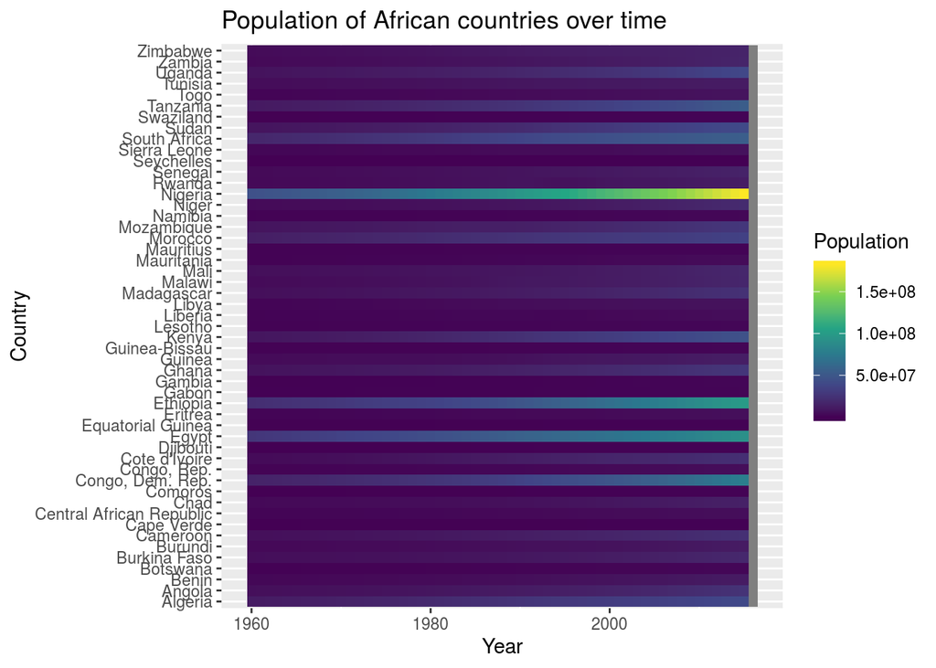

```r
gapminder_africa %>%
  ggplot(aes(x = year, y = country, fill = population)) +
  geom_tile() +
  xlab("Year") + ylab("Country") +
  ggtitle("Population of African countries over time") +
  scale_fill_viridis_c(name = "Population")
```

Also note that we can use the `name` parameter in the `scale_` functions to set the title of the legend.

6. The previous plot was hard to read because the countries were in alphabetical order. Instead, maybe we can order the countries by the maximum population (i.e. the population they reached in the most recent year available in gapminder).

First, use `group_by` and `summarize` to calculate the maximum population (over years) for each country.

```r
gapminder_africa %>%
  group_by(country) %>%
  summarize(max_pop = max(population))
```

```
## # A tibble: 51 x 2
##    country                  max_pop
##    <fct>                      <dbl>
##  1 Algeria                       NA
##  2 Angola                        NA
##  3 Benin                         NA
##  4 Botswana                      NA
##  5 Burkina Faso                  NA
##  6 Burundi                       NA
##  7 Cameroon                      NA
##  8 Cape Verde                    NA
##  9 Central African Republic      NA
## 10 Chad                          NA
## # … with 41 more rows
```

```r
gapminder_africa %>%
  group_by(country) %>%
  summarize(max_pop = max(population, na.rm = TRUE))
```

```
## # A tibble: 51 x 2
##    country                   max_pop
##    <fct>                       <dbl>
##  1 Algeria                  39666519
##  2 Angola                   25021974
##  3 Benin                    10879829
##  4 Botswana                  2262485
##  5 Burkina Faso             18105570
##  6 Burundi                  11178921
##  7 Cameroon                 23344179
##  8 Cape Verde                 520502
##  9 Central African Republic  4900274
## 10 Chad                     14037472
## # … with 41 more rows
```

Note, because of missing data, we need to use `max` with `na.rm = TRUE` to remove the NAs.

7. Now, using the `reorder` function, create a new column `country_reorder` in the `gapminder_africa` data that reorders the countries by their maximum population over all the years in the gapminder data.

```r
gapminder_africa <- gapminder_africa %>%
  mutate(country_reorder = reorder(country, population, max,
                                   na.rm = TRUE))
```

8. Finally, use the `country_reorder` variable to make a revised version of the plot in part (e).

Also, note that `ggplot2` `scale` functions also take a `trans` argument, so you can apply a transformation to the scale. Apply a log10 transformation to the fill.

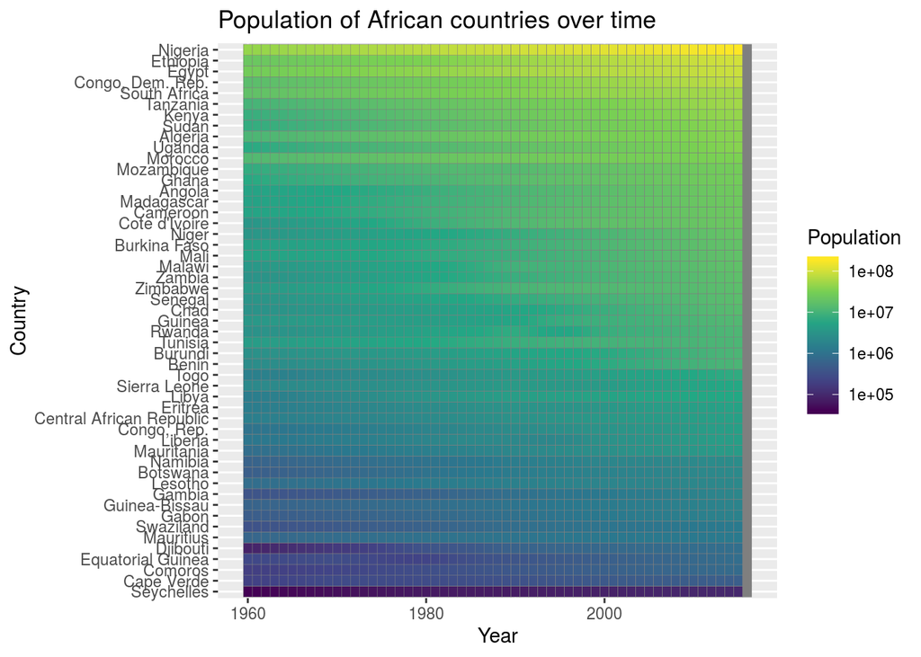

```r
gapminder_africa %>%
  ggplot(aes(x = year, y = country_reorder, fill = population)) +
  geom_tile(color = "grey50") +
  scale_fill_viridis_c(name = "Population", trans = "log10") +
  xlab("Year") + ylab("Country") +
  ggtitle("Population of African countries over time")
```